# EDA - Zdrowie psychiczne Studentów (University Students’ Mental Health)

## 3. Jak wiek wpływa na występowanie problemów psychicznych, takich jak depresja, lęk czy ataki paniki?

Moja analiza ma pokazać, czy młodsi lub starsi studenci są bardziej podatni na problemy psychiczne.

Na początku przygotuje dane do analizy:

```r
zdrowie_psychiczne <- mentalhealth_data %>%
  select(Wiek = Age, Depresja = Depression, Lek = Anxiety, AtakiPaniki = PanicAttack) %>%
  mutate(
    Depresja = as.numeric(as.character(Depresja)),
    Lek = as.numeric(as.character(Lek)),
    AtakiPaniki = as.numeric(as.character(AtakiPaniki))
  ) %>%
  pivot_longer(
    cols = c(Depresja, Lek, AtakiPaniki),
    names_to = "Problem",
    values_to = "Występowanie"
  )
```

Tworze wykres:

```r
wykres_wiek_problemy <- ggplot(zdrowie_psychiczne, aes(x = Wiek, fill = factor(Występowanie))) +
  geom_histogram(position = "dodge", binwidth = 1) +
  facet_wrap(~ Problem) +
  labs(
    title = "Wpływ wieku na występowanie problemów psychicznych",
    x = "Wiek",
    y = "Liczba studentów",
    fill = "Występowanie problemu"
  ) +
  theme_minimal() +
  theme(
    legend.position = "top",
    plot.title = element_text(size = 14, face = "bold"),
    axis.title = element_text(size = 12),
    legend.title = element_text(size = 12, face = "bold"),
    legend.text = element_text(size = 10)
  )
```

Wyświetlam wyniki:

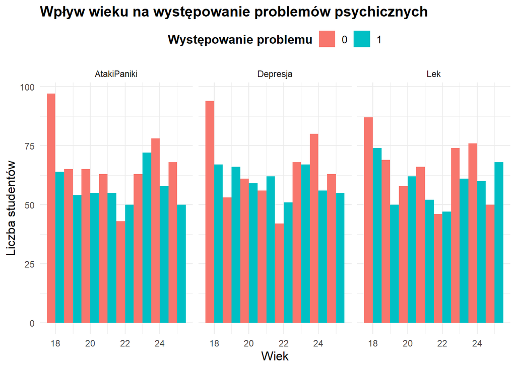

```r
wykres_wiek_problemy
```

## 4. Czy liczba godzin nauki w tygodniu wiąże się z poziomem stresu studentów?

Na początku ustawiam zmienną StudyStressLevel jako typ factor

```r
mentalhealth_data$StudyStressLevel <- factor(mentalhealth_data$StudyStressLevel)
```

Tworze wykres:

```r
wykres_godzin_nauki <- ggplot(mentalhealth_data, aes(x = StudyHoursPerWeek, fill = factor(StudyStressLevel))) +
  geom_density(alpha = 0.7) +
  scale_fill_manual(
    values = c("red", "orange", "yellow", "lightblue", "lightgreen"), # Czerwony pasowałby na najwyższy stres, ale zasłaniał inne kolory więc jest na odwrót
    labels = c("Stres 1 (najniższy)", "Stres 2", "Stres 3", "Stres 4", "Stres 5 (najwyższy)")
  ) +
  labs(
    title = "Rozkład godzin nauki w zależności od poziomu stresu",
    x = "Liczba godzin nauki w tygodniu",
    y = "Gęstość",
    fill = "Poziom stresu"
  ) +
  theme_minimal() +
  theme(
    legend.position = "top",
    legend.title = element_text(size = 12, face = "bold"),
    legend.text = element_text(size = 10),
    plot.title = element_text(size = 14, face = "bold"),
    axis.title = element_text(size = 12)
  )
```

Wyświetlam wyniki:

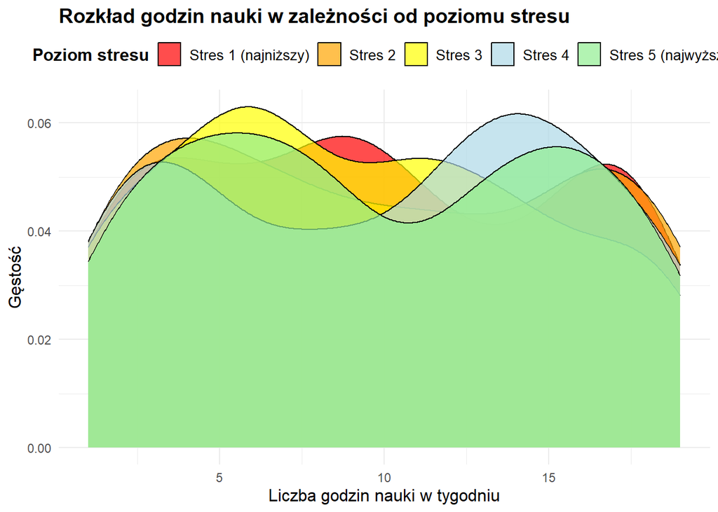

```r
wykres_godzin_nauki
```

## 5. Czy rodzaj kierunku studiów wpływa na jakość snu i poziom stresu naukoweg studentów?

### Wykres jakości snu w zależności od kierunku studiów:

Na początku ustawiam zmienną SleepQuality jako typ factor

```r
mentalhealth_data$SleepQuality <- factor(mentalhealth_data$SleepQuality)
```

Tworze wykres:

```r
wykres_jakosc_snu <- ggplot(mentalhealth_data, aes(x = Course, fill = SleepQuality)) +
  geom_bar(position = "fill", width = 0.9) +
  labs(
    title = "Procentowy rozkład jakości snu w zależności od kierunku studiów",
    x = "Kierunek studiów",
    y = "Procent",
    fill = "Jakość snu"
  ) +
  scale_y_continuous(labels = scales::percent) +
  scale_fill_brewer(palette = "Set3") +
  theme_minimal() +
  theme(
    axis.text.x = element_text(angle = 90, hjust = 1, vjust = 0.5, size = 10),
    axis.title = element_text(size = 12),
    plot.title = element_text(size = 14, face = "bold")
  )
```

Wyświetlam wyniki:

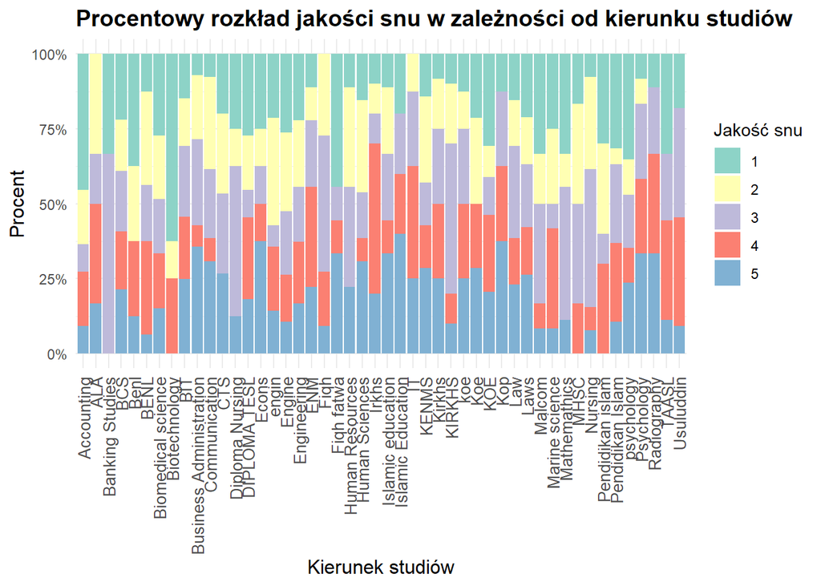

```r
wykres_jakosc_snu
```

#### Wykres dane:

- 1 oznacza bardzo złą jakość snu,
- 5 oznacza bardzo dobrą jakość snu.

### Wykres poziomu stresu w zależności od kierunku studiów

Na początku ustawiam zmienną StudyStressLevel jako typ factor

```r
mentalhealth_data$StudyStressLevel <- factor(mentalhealth_data$StudyStressLevel)
```

Tworze wykres:

```r
wykres_poziomu_stresu <- ggplot(mentalhealth_data, aes(x = Course, fill = StudyStressLevel)) +
  geom_bar(position = "fill", width = 0.9) +
  labs(
    title = "Procentowy rozkład poziomu stresu w zależności od kierunku studiów",
    x = "Kierunek studiów",
    y = "Procent",
    fill = "Poziom stresu"
  ) +
  scale_y_continuous(labels = scales::percent) +
  scale_fill_brewer(palette = "Set3") +
  theme_minimal() +
  theme(
    axis.text.x = element_text(angle = 90, hjust = 1, vjust = 0.5, size = 10),
    axis.title = element_text(size = 12),
    plot.title = element_text(size = 14, face = "bold")
  )
```

Wyświetlam wyniki:

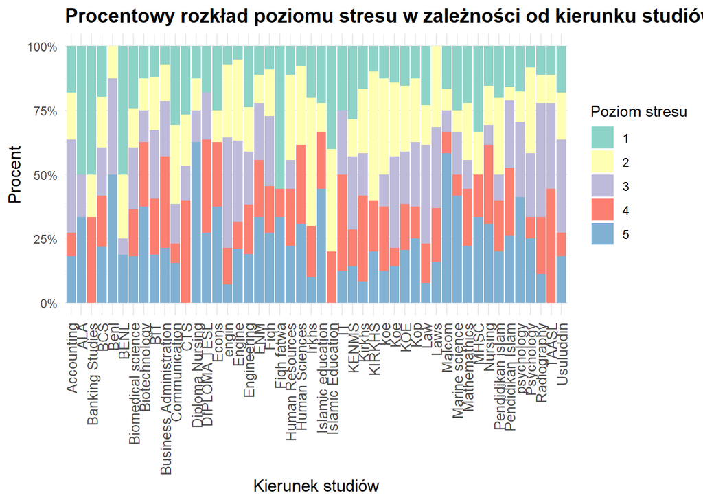

```r
wykres_poziomu_stresu
```

##### Wykres dane:

- 1 oznacza mało stresu,
- 5 oznacza dużo stresu.

##### Wyniki:

Dzięki powyższemu wykresowi można zauważyć, że widoczna jest duża róznica między kierunkami. Na niektórych kierunkach np. Diploma Nursing przeważają wyższe poziomy stresu. Kierunki które mają niższy poziom stresu to np. Law. Na niektórych kierunkach np. Business Administration poziomy stresu są bardziej równomiernie rozłożone, co może wskazywać na różnorodne doświadczenia studentów.

## 6. Jak liczba godzin nauki tygodniowo (StudyHoursPerWeek) wpływa na średnią ocen studentów (CGPA)?

CGPA to Cumulative Grade Point Average . W szkołach i college’ach CGPA jest używane do mierzenia ogólnych osiągnięć akademickich ucznia poprzez przyznawanie ocen A, B, C, D lub F.

```r
godziny_nauki_oceny <- ggplot(mentalhealth_data, aes(x = StudyHoursPerWeek, y = CGPA)) +
  geom_point(color = "blue", alpha = 0.6) +
  geom_smooth(method = "lm", se = TRUE, color = "red") +
  labs(
    title = "Zależność między liczbą godzin nauki tygodniowo a średnią ocen (CGPA)",
    x = "Liczba godzin nauki tygodniowo",
    y = "Średnia ocen (CGPA)"
  ) +
  theme_bw()
```

Wyświetlam wyniki:

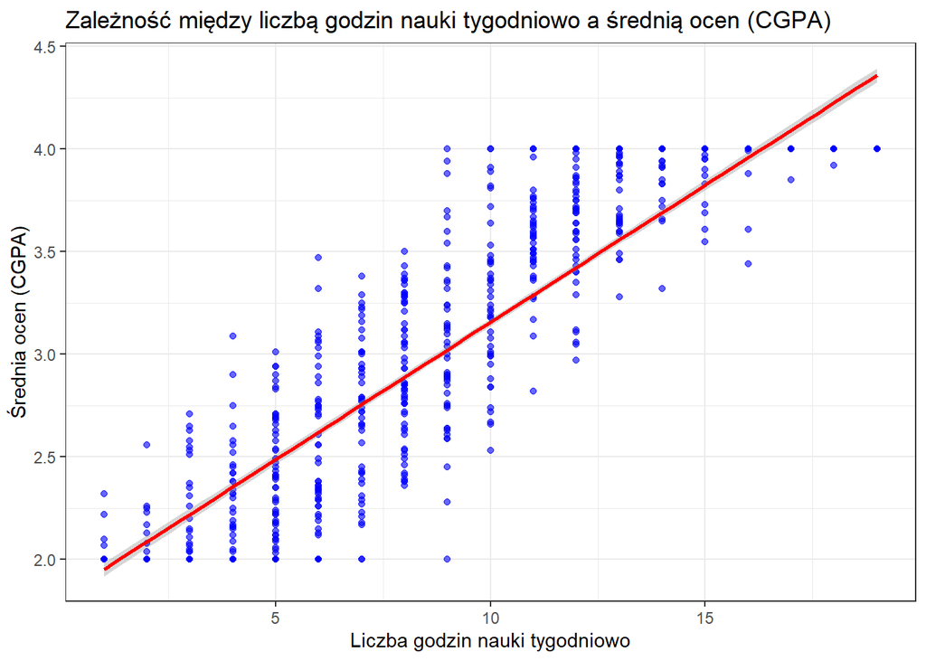

```r
godziny_nauki_oceny
```

#### Wyniki:

Dzięki powyższemu wykresowi widać dodatnią korelację: wraz ze wzrostem liczby godzin nauki tygodniowo, średnia ocen (CGPA) również wzrasta. Linia trendu (regresji) wskazuje na stały, liniowy wzrost CGPA wraz z liczbą godzin nauki. Jednak można zobaczyć pewne rozproszenie punktów wokół linii regresji, co sugeruje, że choć istnieje pozytywny trend, nie wszystkie dane dokładnie pasują do tej zależności. Więc sumując można powiedzieć, że jest pozytywna zależność między liczbą godzin nauki a średnią ocen — więcej nauki w tygodniu wiąże się z wyższą CGPA.

## 7. Czy studenci korzystające ze wsparcia psychologicznego (HasMentalHealthSupport) rzadziej doświadczają ataków paniki (PanicAttack)?

```r
atak_paniki_wsparcie <- ggplot(mentalhealth_data %>%
                                 group_by(HasMentalHealthSupport, PanicAttack) %>%
                                 summarise(liczba = n()) %>%
                                 mutate(procent = liczba / sum(liczba) * 100),
                               aes(x = factor(HasMentalHealthSupport, labels = c("Bez wsparcia", "Ze wsparciem")),
                                   y = procent,
                                   fill = factor(PanicAttack, labels = c("Brak ataków", "Ataki paniki")))) +
  geom_bar(stat = "identity", position = "dodge") +
  labs(
    title = "Czy wsparcie psychologiczne zmniejsza częstotliwość ataków paniki?",
    x = "Wsparcie psychologiczne",
    y = "Procent osób",
    fill = "Ataki paniki"
  ) +
  theme_bw() +
  scale_fill_manual(values = c("steelblue", "tomato")) +
  theme(
    plot.title = element_text(size = 14, face = "bold"),
    axis.title = element_text(size = 12),
    axis.text = element_text(size = 10),
    legend.position = "top"
  )
```

Wyświetlam wyniki:

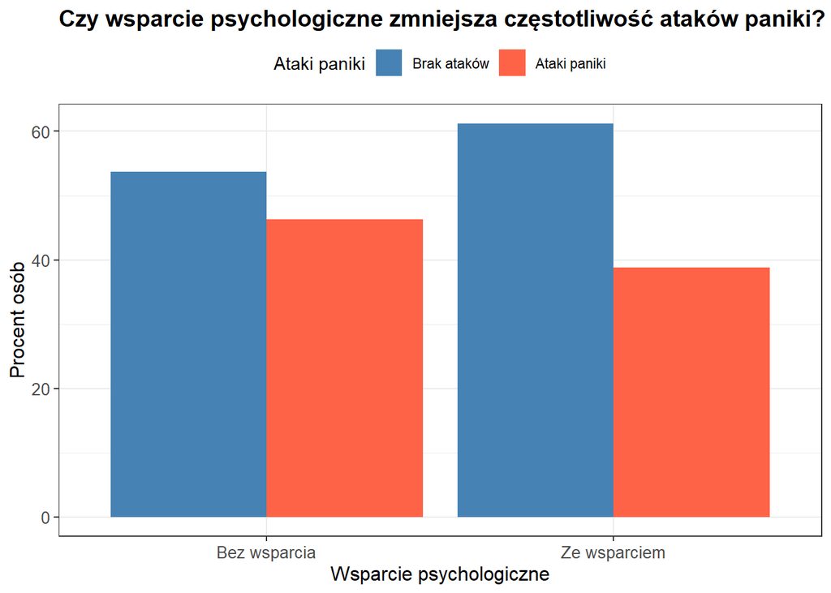

```r
atak_paniki_wsparcie
```

#### Wyniki:

Dzięki powyższemu wykresowi możemy zobaczy, że: - studenci bez wsparcia psychologicznego: w badanej grupie ataki paniki zgłasza niemal połowa osób, a udział studentów, którzy nie doświadczają ataków paniki, jest tylko nieznacznie wyższy. - studenci ze wsparciem psychologicznym: w tej grupie odsetek osób doświadczających ataków paniki jest widocznie mniejszy, a wyraźnie przeważa odsetek osób, które nie zgłaszają takich problemów.

## 8. Czy dostęp do wsparcia psychologicznego różni się w zależności od kierunku studiów?

```r
wsparcie_kierunek <- ggplot(mentalhealth_data %>%
                            group_by(Course, HasMentalHealthSupport) %>%
                            summarise(liczba = n()) %>%
                            mutate(procent = liczba / sum(liczba) * 100),
                          aes(x = Course, y = procent, fill = factor(HasMentalHealthSupport, labels = c("Brak wsparcia", "Ze wsparciem")))) +
  geom_bar(stat = "identity", position = "stack") +
  labs(
    title = "Dostęp do wsparcia psychologicznego w zależności od kierunku studiów",
    x = "Kierunek studiów",
    y = "Procent studentów",
    fill = "Wsparcie psychologiczne"
  ) +
  theme_bw() +
  scale_fill_manual(values = c("tomato", "lightblue")) +
  theme(
    plot.title = element_text(size = 14, face = "bold"),
    axis.title = element_text(size = 12),
    axis.text = element_text(size = 10),
    legend.position = "top",
    axis.text.x = element_text(angle = 90, hjust = 1, vjust = 0.5)
  )
```

Wyświetlam wyniki:

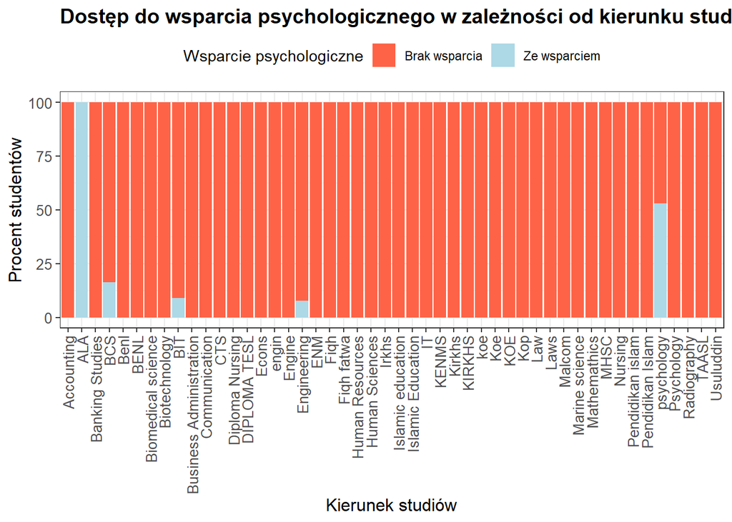

```r
wsparcie_kierunek
```